# R Markdown

Thomas Holland (th675)

December 22, 2022

```r
knitr::opts_chunk$set(echo = TRUE)
# disable warnings
options(warn=-1)

# libraries used can be installed using the following commands
# install.packages("tidyverse")
# install.packages("rmarkdown")
# install.packages("rmdformats") # for custom html output, using the html_clean format

# load libraries
library(tidyverse)
library(knitr)
```

Click the images to view larger versions.

# 1 Inital data import

## 1.1 Import data

```r
# load data from data.csv using read_csv from the tidyverse package
data <- read_csv("data.csv")
kable(head(data))
```

| length | sex |
| --- | --- |
| 17.9 | female |
| 10.6 | female |
| 12.2 | female |
| 20.4 | female |
| 15.5 | female |
| 19.1 | female |

## 1.2 Data cleaning

```r
# print number of rows with missing values
sum(is.na(data))
```

```
## [1] 0
```

## 1.3 Log transformation of size data

```r
# add new column to data with natural log transformed length

data <- data %>%
    mutate(log_length = log(length))

kable(head(data))
```

| length | sex | log_length |
| --- | --- | --- |
| 17.9 | female | 2.884801 |
| 10.6 | female | 2.360854 |
| 12.2 | female | 2.501436 |
| 20.4 | female | 3.015535 |
| 15.5 | female | 2.740840 |
| 19.1 | female | 2.949688 |

# 2 Basic examination of data

## 2.1 Box plot of data

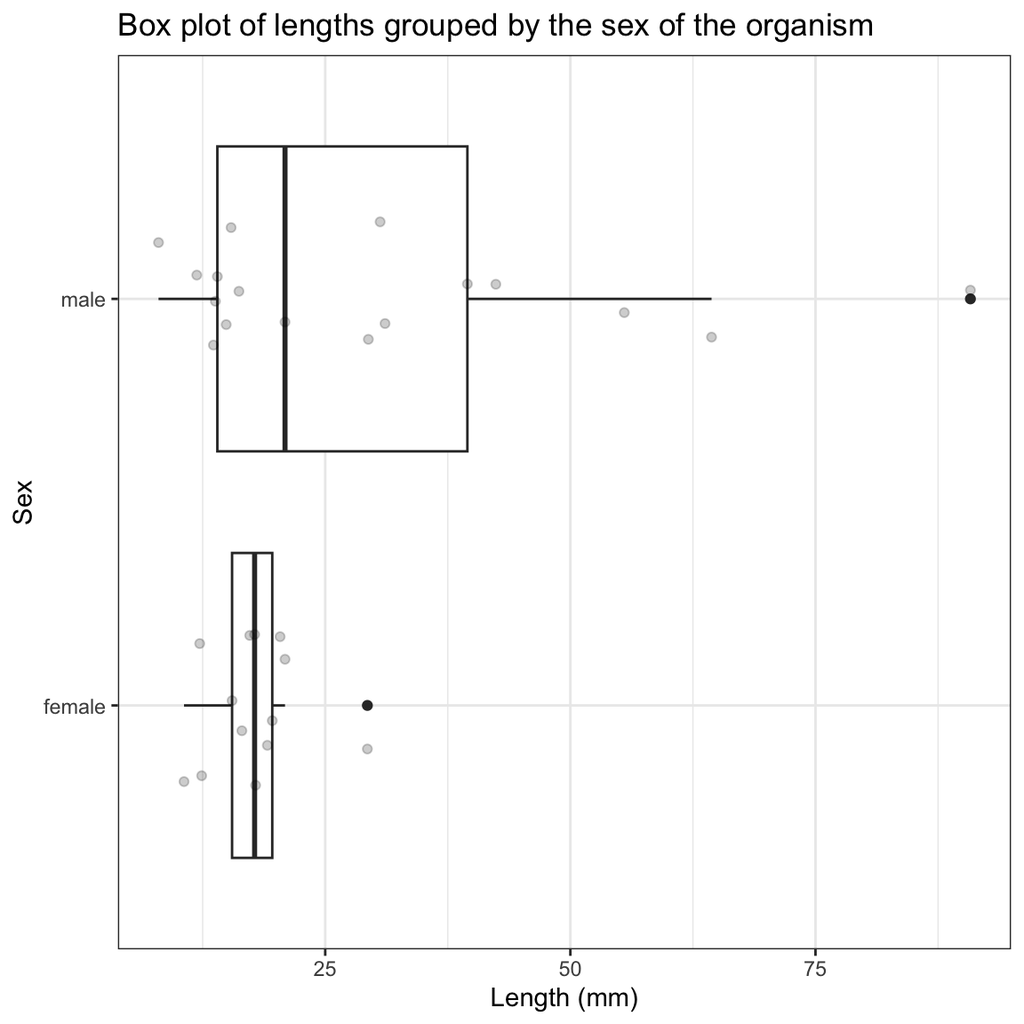

```r
# box plot of length, grouped by sex from the dataset data, using the ggplot2 package.

ggplot(data, aes(length, sex)) +
    geom_boxplot() +
    geom_jitter(width = 0, height = 0.2, alpha = 0.2) +  # added jitter so overlapping points are visible
    theme_bw() +
    labs(title="Box plot of lengths grouped by the sex of the organism", x="Length (mm)" , y="Sex")
```

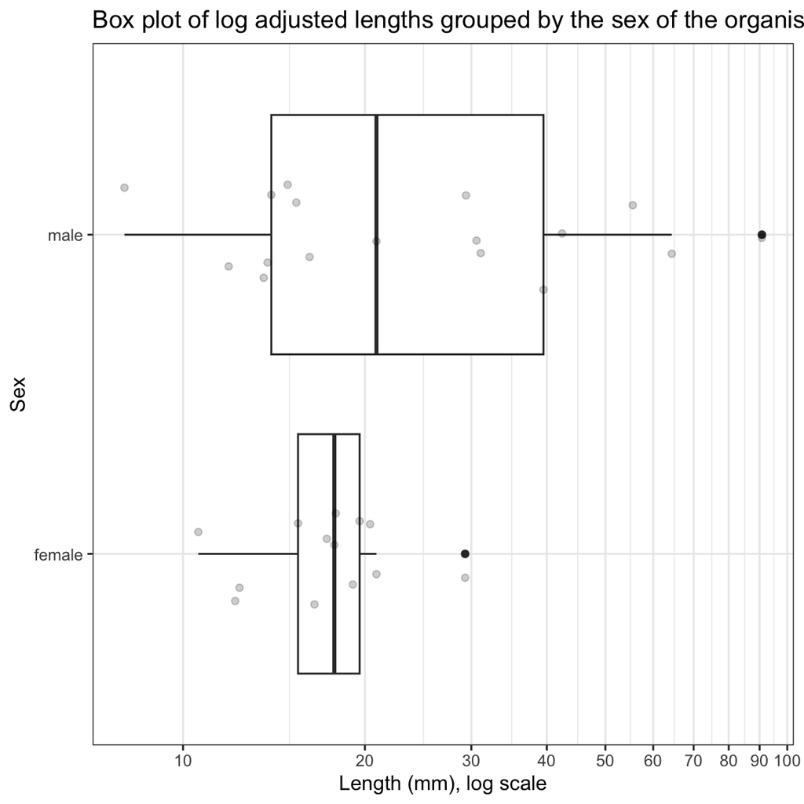

```r
# box plot of lengths, grouped by sex from the dataset data, using the ggplot2 package. Add x scale every 10 mm

ggplot(data, aes(length, sex)) +
    geom_boxplot() +
    geom_jitter(width = 0, height = 0.2, alpha = 0.2) +  # added jitter so overlapping points are visible
    theme_bw() +
    coord_trans(x = "log") + # transform the x axis to natural  log scale
    scale_x_continuous(breaks = seq(0, 100, 10)) + # add more values to the x axis
    labs(title="Box plot of log adjusted lengths grouped by the sex of the organism", x="Length (mm), log scale" , y="Sex")
```

# 3 Statistical tests

This section contains the results of the statistical tests carried out on the data. The analysis of these results and comments are in the analysis section.

## 3.1 Binomial test

Carry out and report the results of a binomial test to evaluate whether the sex ratio of the sample deviates from 1:1.

```r
binomial <- binom.test(table(data$sex), p = 0.5, alternative = "two.sided", conf.level = 0.95)

binomial
```

```
##
##  Exact binomial test
##
## data:  table(data$sex)
## number of successes = 13, number of trials = 30, p-value = 0.5847
## alternative hypothesis: true probability of success is not equal to 0.5
## 95 percent confidence interval:
##  0.2546075 0.6257265
## sample estimates:
## probability of success
##              0.4333333
```

## 3.2 T-test

Carry out and report the results of a t-test to evaluate whether females and males differ in size.

```r
lm.t_test <- lm(data$length ~ data$sex)
lm.t_test
```

```
##
## Call:
## lm(formula = data$length ~ data$sex)
##
## Coefficients:
##  (Intercept)  data$sexmale
##        17.65         12.49
```

```r
summary(lm.t_test)
```

```
##
## Call:
## lm(formula = data$length ~ data$sex)
##
## Residuals:
##     Min      1Q  Median      3Q     Max
## -22.141 -12.766  -0.548   2.546  60.659
##
## Coefficients:
##              Estimate Std. Error t value Pr(>|t|)
## (Intercept)    17.654      4.793   3.683 0.000976 ***
## data$sexmale   12.487      6.367   1.961 0.059868 .
## ---
## Signif. codes:  0 '***' 0.001 '**' 0.01 '*' 0.05 '.' 0.1 ' ' 1
##
## Residual standard error: 17.28 on 28 degrees of freedom
## Multiple R-squared:  0.1208, Adjusted R-squared:  0.08938
## F-statistic: 3.846 on 1 and 28 DF,  p-value: 0.05987
```

```r
t.test(data$length ~ data$sex, alternative = "two.sided", conf.level = 0.95, var.equal = TRUE)
```

```
##
##  Two Sample t-test
##
## data:  data$length by data$sex
## t = -1.9612, df = 28, p-value = 0.05987
## alternative hypothesis: true difference in means between group female and group male is not equal to 0
## 95 percent confidence interval:
##  -25.529830   0.555169
## sample estimates:
## mean in group female   mean in group male
##             17.65385             30.14118
```

### 3.2.1 Diagnostic plots for t-test

Use histogram for diagnostic plots for the t-test.

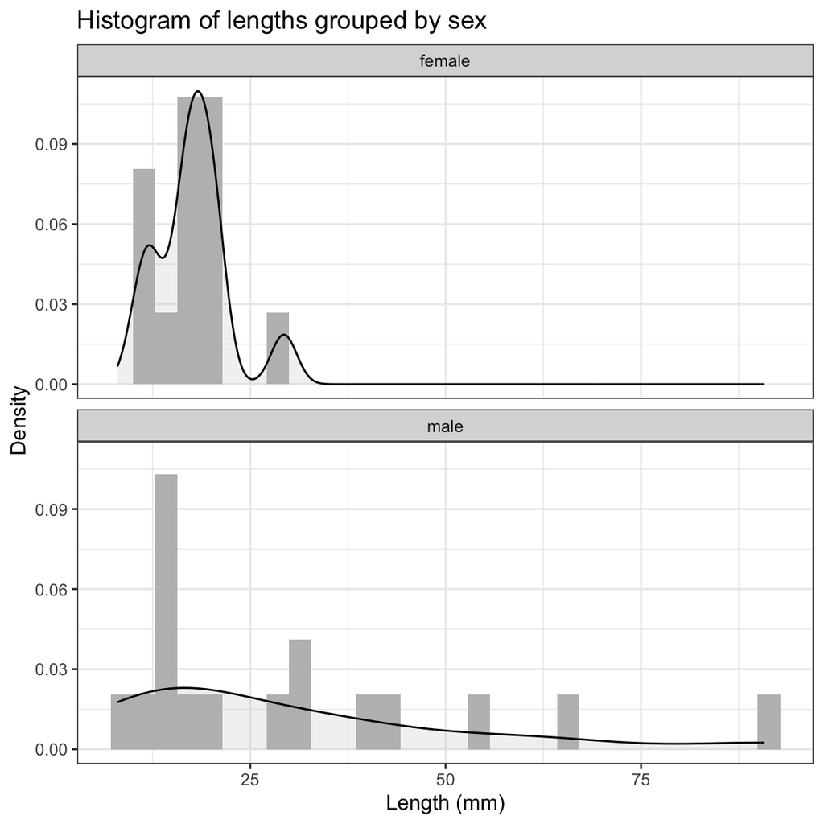

```r
ggplot(data = data, aes(x = length)) +
    geom_histogram(aes(y = ..density..), bins = 30, fill = "grey") +
    geom_density(alpha = 0.2, fill = "grey") +
    facet_wrap(~sex, ncol = 1) +
    theme_bw() +
    labs(title="Histogram of lengths grouped by sex", x="Length (mm)" , y="Density")
```

Also use the built-in diagnostic plots for the t-test.

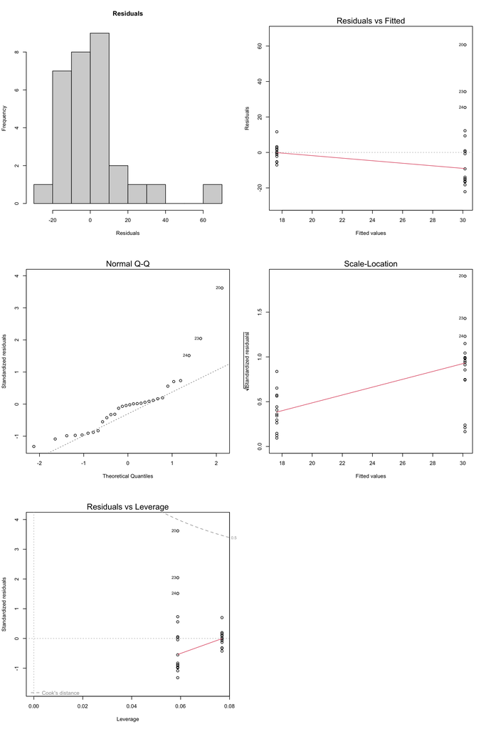

```r
par(mfrow = c(3,2))
hist(resid(lm.t_test), main = "Residuals", xlab = "Residuals", ylab = "Frequency")
plot(lm.t_test)
```

## 3.3 Mann-Whitney U test

Non-parametric alternative to the t-test.

```r
mannwhitney <- wilcox.test(data$length ~ data$sex, alternative = "two.sided", conf.level = 0.95)

mannwhitney
```

```
##
##  Wilcoxon rank sum test with continuity correction
##
## data:  data$length by data$sex
## W = 85.5, p-value = 0.3051
## alternative hypothesis: true location shift is not equal to 0
```

The diagnostic plots for the t-test can also be used for the Mann-Whitney U test.

## 3.4 T-test on log transformed data

```r
lm.log_t_test <- lm(log(data$length) ~ data$sex)
lm.log_t_test
```

```
##
## Call:
## lm(formula = log(data$length) ~ data$sex)
##
## Coefficients:
##  (Intercept)  data$sexmale
##       2.8382        0.3408
```

```r
summary(lm.log_t_test)
```

```
##
## Call:
## lm(formula = log(data$length) ~ data$sex)
##
## Residuals:
##      Min       1Q   Median       3Q      Max
## -1.09956 -0.43198  0.02672  0.23199  1.32966
##
## Coefficients:
##              Estimate Std. Error t value Pr(>|t|)
## (Intercept)    2.8382     0.1506  18.846   <2e-16 ***
## data$sexmale   0.3408     0.2001   1.703   0.0996 .
## ---
## Signif. codes:  0 '***' 0.001 '**' 0.01 '*' 0.05 '.' 0.1 ' ' 1
##
## Residual standard error: 0.543 on 28 degrees of freedom
## Multiple R-squared:  0.09389,    Adjusted R-squared:  0.06153
## F-statistic: 2.901 on 1 and 28 DF,  p-value: 0.09959
```

```r
t.test(log(data$length) ~ data$sex, alternative = "two.sided", conf.level = 0.95, var.equal = TRUE)
```

```
##
##  Two Sample t-test
##
## data:  log(data$length) by data$sex
## t = -1.7033, df = 28, p-value = 0.09959
## alternative hypothesis: true difference in means between group female and group male is not equal to 0
## 95 percent confidence interval:
##  -0.75059345  0.06904371
## sample estimates:
## mean in group female   mean in group male
##             2.838229             3.179004
```

```r
t.test(log(data$length) ~ data$sex, alternative = "two.sided", conf.level = 0.95, var.equal = FALSE)
```

```
##
##  Welch Two Sample t-test
##
## data:  log(data$length) by data$sex
## t = -1.8849, df = 21.896, p-value = 0.07278
## alternative hypothesis: true difference in means between group female and group male is not equal to 0
## 95 percent confidence interval:
##  -0.71581651  0.03426678
## sample estimates:
## mean in group female   mean in group male
##             2.838229             3.179004
```

### 3.4.1 Diagnostic plots for t-test on log transformed data

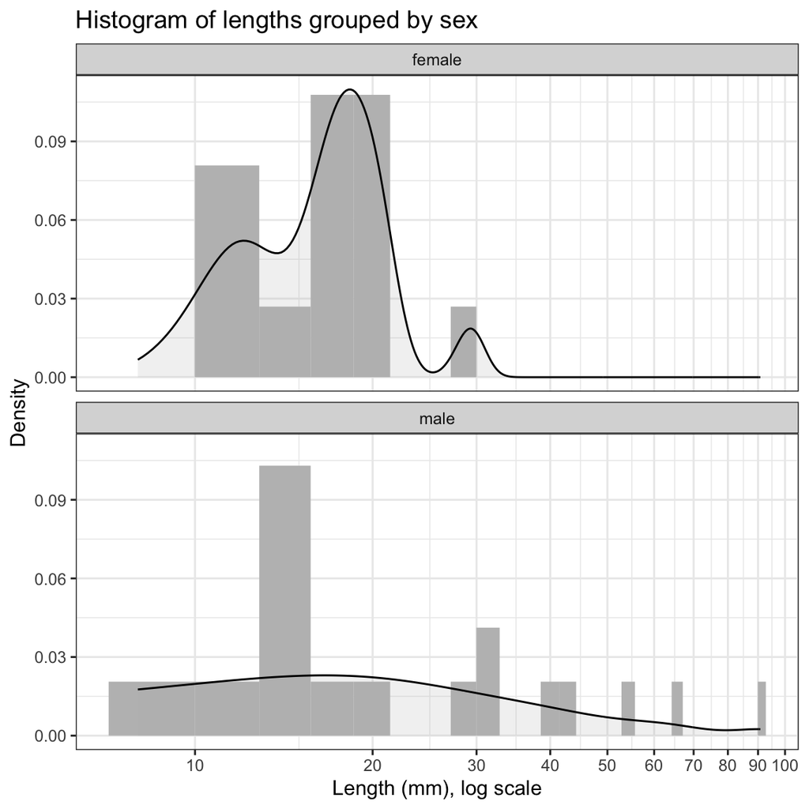

```r
ggplot(data = data, aes(x = length)) +
    geom_histogram(aes(y = ..density..), bins = 30, fill = "grey") +
    geom_density(alpha = 0.2, fill = "grey") +
    facet_wrap(~sex, ncol = 1) +
    theme_bw() +
    coord_trans(x = "log") + # transform the x axis to natural  log scale
    scale_x_continuous(breaks = seq(0, 100, 10)) + # add more values to the x axis
    labs(title="Histogram of lengths grouped by sex", x="Length (mm), log scale" , y="Density")
```

Utilising the built-in diagnostic plots for the t-test.

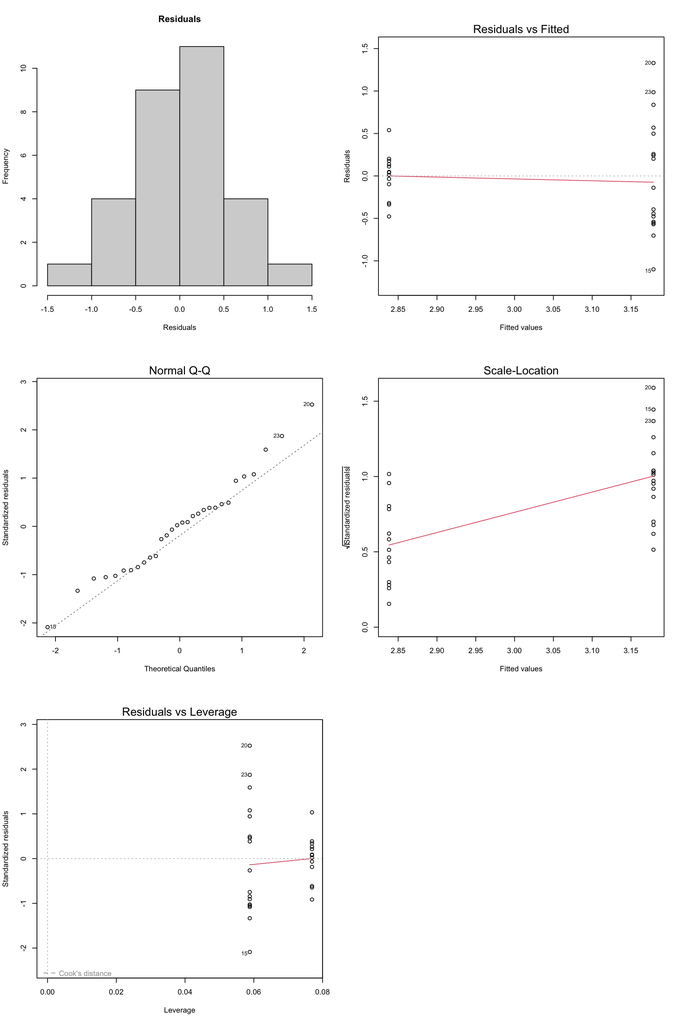

```r
par(mfrow = c(3,2))
hist(resid(lm.log_t_test), main = "Residuals", xlab = "Residuals", ylab = "Frequency")
plot(lm.log_t_test)
```

# 4 Analysis

## 4.1 Binomial test

The binomial test confirmed that there was no significant deviation from the sex ratio displayed in the data because the p-value of 0.5846647 is greater than the significance level of 0.05.

## 4.2 T-test

However, the diagnostic plots for the linear model generated from this is not ideal. Firstly, the histogram plot shows an unequal variance, as the male group has a much larger variance. Also, the histogram plot shows that there is a non-normal distribution with the male having a possible positive skew.

This is also seen with the residuals vs fitted diagnostic plot that has a much smaller spread around the female group (the lower fitted value). Also in the normal Q-Q plot, the datapoints stray quite far from the 1:1 expectation line, especially at either end suggesting that a transformation may be necessary.

This is confirmed as the Mann-Whitney U test had a non-significant result (p-value of 0.3051358), confirming that even without parametric assumptions the data is not significantly different, and so a transformation may be necessary.

However, based on the linear model generated using the log-transformations, there is no significant predictive value of sex in the length of the fish (p-value of 0.0995879, equal variance), and even when testing without the assumption of equal variance the predictive value is still not significant (p-value of 0.0727845).

*Please note that there is “hidden” code within this that is used to access the p-values by using the following code as an example: `` `r mannwhitney$p.value` ``*